# Analiza zależności między PKB per capita a poziomem szczęścia w ujęciu globalnym i kontynentalnym w latach 2014-2023

Projekt zaliczeniowy z Programowania w R

Autorzy: Sylwester Sowula, Adam Łukasik

2026-07-26

## Wprowadzenie teoretyczne - Dane

Celem niniejszej pracy jest zbadanie zależności między poziomem PKB per capita a poziomem szczęścia. W naszej pracy korzystamy z dwóch kluczowych pojęć:

- Poziom szczęścia (Life Satisfaction) – w naszych badań jest on mierzony za pomocą Skali Cantrila, w której badani oceniają poziom swojego życia w skali od 0 do 10, gdzie 0 to najgorsze możliwe życie, a 10 to najlepsze możliwe.
- PKB per capita (GDP per capita) – jest to wskaźnik ekonomiczny mierzący wartość wszystkich dóbr i usług wytworzonych w kraju w danym roku, podzielony przez liczbę mieszkańców. W naszych badaniach jest on wyrażony w USD.

## Wprowadzenie teoretyczne - Źródła i Przygotowanie danych

- W naszej pracy posłużymy się danymi z bazy danych ([Our World in Data](https://ourworldindata.org/));
- Aby zapewnić spójność czasową ograniczyliśmy zakres od 2014 do 2023 roku;
- Przefiltrowaliśmy dane i usunęliśmy brakujące dane (`na.omit`), co pozwoli przeprowadzić kompletną analizę;
- Połączyliśmy nasze tabele z danymi i dołączyliśmy zmienną kategoryczną ‘Continent’, która pozwoli nam przeanalizować naszą zależność na każdym z kontynentów.

## Analiza danych

- Przedstawimy podstawowe statystyki opisowe (np. min, max czy średnia) dla PKB per capita i poziomu szczęścia, aby uzyskać ogólny pogląd o naszych danych. Wykonaliśmy je zarówno dla całego zbioru, jak i poszczególnych kontynentów.
- Zbadamy trendy czasowe według kontynentu i roku. Obliczymy średni poziom szczęścia i PKB per capita w każdym roku i przedstawimy jako wykres liniowy na osi czasu.
- Zbadamy regresję. Najpierw stworzymy wykresy punktowe, gdzie zmienną objaśniającą jest PKB per capita, a zmienną objaśnianą jest poziom szczęścia, na które następnie nałożymy linie regresji. Aby lepiej określić charakter rozkładu danych, posłużymy się trzema modelami: liniowym, logarytmicznym i pierwiastkowym. Wykonamy to dla całego zbioru, jak i każdego kontynentu.

## Użyte Pakiety i ich funkcje

**`shiny` (Autorzy: Winston Chang i zespół Posit)** Podstawowy pakiet do budowania interaktywnych aplikacji webowych.

- **Logika UI:** `fluidPage()`, `tabsetPanel()`, `sidebarLayout()`, i `mainPanel()` tworzą strukturę i układ zakładek.
- **Kontrolki:** `sliderInput()`, `selectInput()`, `radioButtons()` i `checkboxGroupInput()` pozwalają użytkownikowi na interaktywne filtrowanie danych.
- **Wyjścia:** `plotOutput()` i `verbatimTextOutput()` rezerwują miejsce w UI na dynamicznie generowane wykresy i tekst.
- **Logika Serwera:** `reactive({})` tworzy obiekty, które automatycznie przeliczają się, gdy zmienią się filtry.
- **Renderowanie:** `renderPlot({})` i `renderPrint({})` wykonują kod R i renderują jego wynik w odpowiednim miejscu UI.

**`dplyr` (Autor: Hadley Wickham)** Niezbędny pakiet do manipulacji danymi (część *tidyverse*). Używaliśmy go do filtrowania, łączenia, grupowania i agregowania naszych danych o PKB i szczęściu.

- **Filtrowanie:** `filter()` był używany do dynamicznego wybierania danych na podstawie suwaków lat i wyboru kontynentów.
- **Agregacja:** `group_by() %>% summarise()` to kluczowa kombinacja użyta do obliczenia średnich rocznych (`avg_data`) dla wykresów liniowych.
- **Łączenie:** `inner_join()` i `semi_join()` posłużyły w sekcji przygotowania danych do bezpiecznego połączenia trzech różnych plików CSV.

**`ggplot2` (Autor: Hadley Wickham)** Narzędzie do wizualizacji danych (również *tidyverse*).

- **Wykresy:** `geom_point()` (wykres punktowy), `geom_boxplot()` (boxplot) i `geom_line()` (trend czasowy) tworzą wizualne warstwy wykresów.
- **Linia trendu:** `geom_smooth(method = "lm", formula = ...)` pozwolił na dynamiczne dodawanie różnych modeli regresji (liniowej, logarytmicznej, pierwiastkowej).

**`scales` (Autor: Thomas Lin Pedersen)** Pakiet pomocniczy dla `ggplot2`, który ułatwia formatowanie osi. Użyliśmy go do jednej kluczowej funkcji: `dollar_format()`, aby czytelnie wyświetlać wartości PKB.

**`bslib` (Autor: Carson Sievert)** Pakiet do nowoczesnego stylowania aplikacji Shiny. Wykorzystaliśmy go do szybkiego wdrożenia motywu “pulse” oraz załadowania niestandardowej czcionki Google.

## Statystyki

- **Min. / Max.:** Wskazują najniższą i najwyższą wartość.
- **Mediana (Median):** Wskazuje wartość środkową (2 Kwartyl).
- **Średnia (Mean):** Średnia arytmetyczna.
- **1. Kwartyl / 3. Kwartyl:** Wskazuje 1 i 3 Kwartyl.

|  | PKB per capita | Poziom Szczęścia |
| --- | --- | --- |
|  | Min. : 833.9 | Min. :1.721 |
|  | 1st Qu.: 6203.5 | 1st Qu.:4.633 |
|  | Median : 16061.8 | Median :5.531 |
|  | Mean : 26063.9 | Mean :5.491 |
|  | 3rd Qu.: 40635.1 | 3rd Qu.:6.304 |
|  | Max. :137947.3 | Max. :7.842 |

## Zmiana szczęścia w czasie

Sprawdziliśmy również, jak zmieniała się sytuacja na przestrzeni lat. W tym celu zagregowaliśmy dane do średnich dla kontynentów.

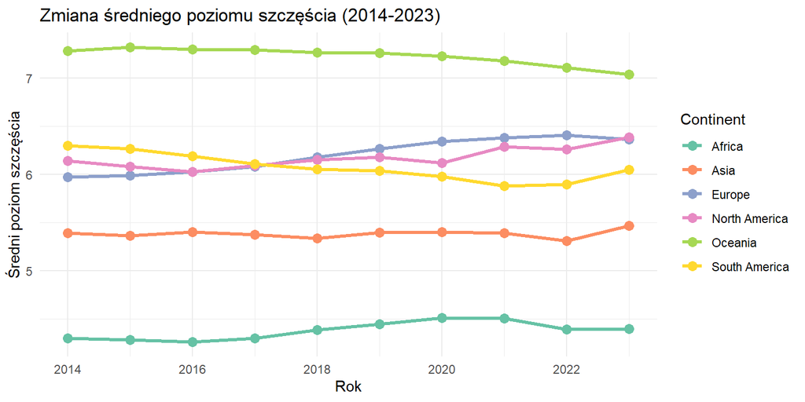

## Zmiana PKB per capita w czasie

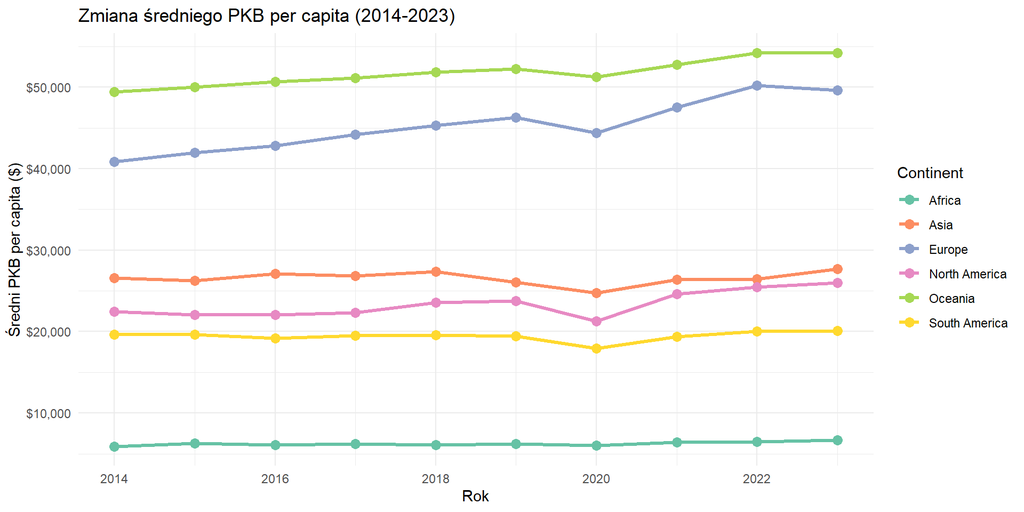

## Regresja (Model Logarytmiczny)

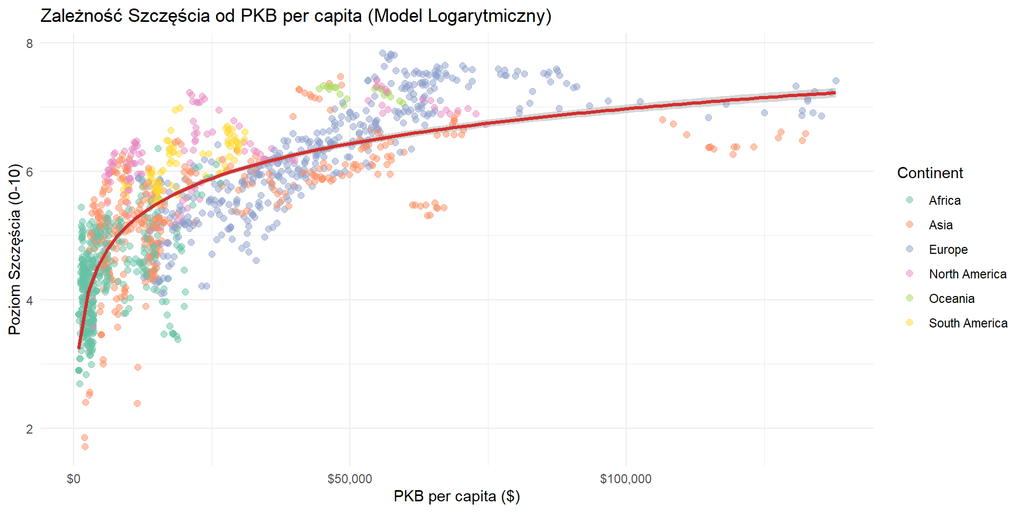

## Regresja (Model Logarytmiczny)

**Analiza:**

Widoczna jest wyraźna, silna korelacja – wraz ze wzrostem zamożności społeczeństwa, rośnie również ich średni poziom zadowolenia z życia.

Kluczową obserwacją jest nieliniowy charakter tej relacji, dlatego użyliśmy tutaj modelu logarytmicznego, który bardzo dobrze ją opisuje. Jest ona stroma dla krajów o niskim PKB, co oznacza, że na tym etapie rozwoju nawet niewielki wzrost dochodu przynosi duży przyrost szczęścia.

W miarę wzrostu zamożności krzywa staje się coraz bardziej płaska, co sugeruje, że w bogatszych krajach dalszy wzrost PKB ma już znacznie mniejszy wpływ na zwiększanie poziomu szczęścia.

## Nierówności w regionach (Boxplot)

**Opis:**

Wykres pudełkowy pozwala nam zobaczyć nie tylko średnią, ale także zróżnicowanie wewnątrz kontynentów.

- “Pudełko” pokazuje zakres, w którym mieści się 50% kraju,
- Kropki to poszczególne kraje, dzięki temu widzimy rozrzut danych

## Boxplot - PKB per capita

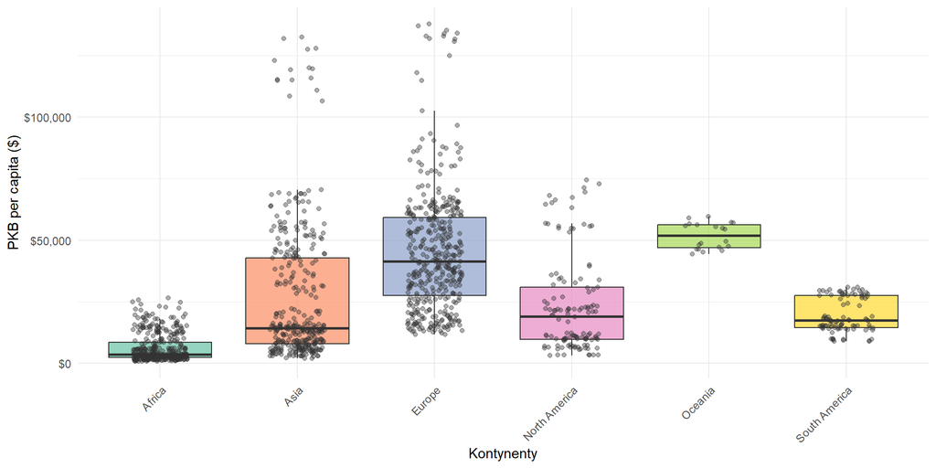

## Boxplot - PKB per capita

**Analiza rozkładu zamożności:**

- **Ogromne dysproporcje w Azji:** Kontynent ten cechuje się największymi nierównościami. Widoczny jest gigantyczny rozrzut – od krajów skrajnie biednych, po jedne z najbogatszych na świecie.
- **Stabilność Oceanii vs różnorodność Europy:** Oba regiony mają wysoką medianę, ale Oceania jest mocno skupiona (kraje o podobnym bogactwie), podczas gdy Europa wykazuje duże zróżnicowanie. Jest to jednak spowodowane niewielką ilością danych dla Oceanii.
- **Afryka:** Charakteryzuje się najniższą medianą, a większość państw jest mocno skoncentrowana w dolnym przedziale wykresu.

## Diagnostyka modelu logarytmicznego oraz jego poprawa

```r
library(lmtest)
library(sandwich)

model <- lm(happiness ~ log(pkb_per_capita),data=app_data)
```

#### Stworzenie funkcji diagnostycznej

```r
validation <- function(model){
  print(summary(model))
  print(shapiro.test(model$residuals))
  print(bptest(model))
  print(dwtest(model))
  print(reset(model))
}
```

#### Diagnostyka

```r
validation(model)
```

```
##
## Call:
## lm(formula = happiness ~ log(pkb_per_capita), data = app_data)
##
## Residuals:
##      Min       1Q   Median       3Q      Max
## -2.88808 -0.43289  0.01757  0.48580  1.83481
##
## Coefficients:
##                     Estimate Std. Error t value Pr(>|t|)
## (Intercept)         -2.01939    0.14846  -13.60   <2e-16 ***
## log(pkb_per_capita)  0.78087    0.01532   50.95   <2e-16 ***
## ---
## Signif. codes:  0 '***' 0.001 '**' 0.01 '*' 0.05 '.' 0.1 ' ' 1
##
## Residual standard error: 0.6653 on 1396 degrees of freedom
## Multiple R-squared:  0.6503, Adjusted R-squared:  0.6501
## F-statistic:  2596 on 1 and 1396 DF,  p-value: < 2.2e-16
##
##
##  Shapiro-Wilk normality test
##
## data:  model$residuals
## W = 0.99128, p-value = 2.267e-07
##
##
##  studentized Breusch-Pagan test
##
## data:  model
## BP = 9.107, df = 1, p-value = 0.002546
##
##
##  Durbin-Watson test
##
## data:  model
## DW = 0.34482, p-value < 2.2e-16
## alternative hypothesis: true autocorrelation is greater than 0
##
##
##  RESET test
##
## data:  model
## RESET = 21.507, df1 = 2, df2 = 1394, p-value = 6.324e-10
```

Widzimy, że zarówno wyraz wolny jak i zmienna objaśniająca są statystycznie istotne. Widzimy również, że model wyjaśnia około 65% zmienności szczęścia.

Z testu Shapiro-Wilka wysnuwa się wniosek, iż reszty modelu nie mają rozkładu normalnego. Nie stanowi to jednak problemu ponieważ dzięki centralnemu twierdzeniu granicznemu wiemy, iż wraz ze wzrostem próby rozkład estymatora OLS zbliża się do rozkładu normalnego.

Test Breuscha-Pagana wskazuje na heteroskedastycznośc - wariancja reszt nie jest stała.

RESET test wskazuje na to, że postać modelu jest niepoprawnie dobrana. Oznacza to, że istnieje inny model niż logarytmicznego, który lepiej wyjaśnia badane zjawisko.

Teraz sprawdzimy jak zachowa się model w pełni zlogarytmizowany (log-log) z odpornymi błędami standardowymi.

```r
model_log <- lm(log(happiness)~log(pkb_per_capita),data=app_data)
coeftest(model_log, vcov = vcovHAC(model_log, type = "HC1"))
```

```
##
## t test of coefficients:
##
##                      Estimate Std. Error t value  Pr(>|t|)
## (Intercept)         0.2419973  0.0768657  3.1483  0.001677 **
## log(pkb_per_capita) 0.1495477  0.0076286 19.6035 < 2.2e-16 ***
## ---
## Signif. codes:  0 '***' 0.001 '**' 0.01 '*' 0.05 '.' 0.1 ' ' 1
```

```r
validation(model_log)
```

```
##
## Call:
## lm(formula = log(happiness) ~ log(pkb_per_capita), data = app_data)
##
## Residuals:
##      Min       1Q   Median       3Q      Max
## -0.83522 -0.07386  0.01108  0.09167  0.37459
##
## Coefficients:
##                     Estimate Std. Error t value Pr(>|t|)
## (Intercept)         0.241997   0.029788   8.124 9.83e-16 ***
## log(pkb_per_capita) 0.149548   0.003075  48.637  < 2e-16 ***
## ---
## Signif. codes:  0 '***' 0.001 '**' 0.01 '*' 0.05 '.' 0.1 ' ' 1
##
## Residual standard error: 0.1335 on 1396 degrees of freedom
## Multiple R-squared:  0.6289, Adjusted R-squared:  0.6286
## F-statistic:  2366 on 1 and 1396 DF,  p-value: < 2.2e-16
##
##
##  Shapiro-Wilk normality test
##
## data:  model$residuals
## W = 0.96093, p-value < 2.2e-16
##
##
##  studentized Breusch-Pagan test
##
## data:  model
## BP = 57.207, df = 1, p-value = 3.923e-14
##
##
##  Durbin-Watson test
##
## data:  model
## DW = 0.39342, p-value < 2.2e-16
## alternative hypothesis: true autocorrelation is greater than 0
##
##
##  RESET test
##
## data:  model
## RESET = 2.3872, df1 = 2, df2 = 1394, p-value = 0.09226
```

Ten zabieg sprawił, że nasz model przeszedł test RESET: nie odrzucamy hipotezy o poprawnej postaci modelu. P-value dla testu na heteroskedastyczność drastycznie zmalało, co potwierdza jej obecność. Jednak zastosowanie odpornych błędów standardowych utwierdziło nas w przekonaniu, że zarówno wyraz wolny, jak i zmienna objaśniająca nadal są statystycznie istotne, a sama heteroskedastyczność oraz autokorelacja nie wpływa na końcową interpretację wyników. Wysnute wcześniej wnioski pozostają dalej aktualne.